# 統計学2

大数の法則

矢内 勇生

2020-08-29（改訂：2021-05-19）

## 準備

必要なパッケージを読み込む。

```r
library(tidyverse)
```

次に、日本語が正しく表示されるようにする。

```r
## 図のなかで日本語を使えるようにする
if (.Platform$OS.type == "windows") {
  # Window
  if (require(fontregisterer)) {
    my_font <- "Yu Gothic"
  } else {
    my_font <- "Japan1"
  }
} else if (capabilities("aqua")) {
  # macOS
  my_font <- "HiraginoSans-W3"
} else {
  # Unix/Linux
  my_font <- "IPAexGothic"
}

theme_set(theme_gray(base_size   = 9,
                     base_family = my_font))
```

## 大数の法則 (Law of Large Numbers; LLN)

「公正な（表が出る確率と裏が出る確率が等しい）」コインを使って、大数の法則のシミュレーションを行う。

コイン投げは、

```r
coin <- c("表", "裏")
sample(coin, size = 1)
```

```
## [1] "表"
```

で行う。

これを一回だけ実行した場合、表の比率は、（1）表が出れば1、（2）裏が出れば0である。コイン投げの回数が少ないと、表が出る比率は真の比率である0.5に近くなるとは限らない。

しかし、大数の法則によると、コインを投げる回数を十分大きくすると、表の比率は0.5 に近づくはずである。Rを使って確かめてみよう。

まず、コインを投げる回数 `n_flips` を決める。500に設定してみよう。

```r
n_flips <- 500
```

次に、結果を記録する容器（ベクトル）を用意する。

```r
ratio_1 <- rep(NA, n_flips)
```

準備ができたので、`n_flips`回コイン投げを行い、それぞれのコイン投げが終わった時点での表の比率を計算する。

```r
coins_1 <- sample(coin, size = n_flips, replace = TRUE)
for (i in 1:n_flips) {
  n_head <- sum(coins_1[1:i] == "表") # i回目までに何回表が出たか数える
  ratio_1[i] <- n_head / i            # i回目までの表の比率を計算して記録する
}
```

これで、`ratio_1` に結果が記録された。確認のため、最初の5回分を表示してみよう。

```r
ratio_1[1:5]
```

```
## [1] 0.00 0.00 0.00 0.25 0.40
```

結果を図示しよう。

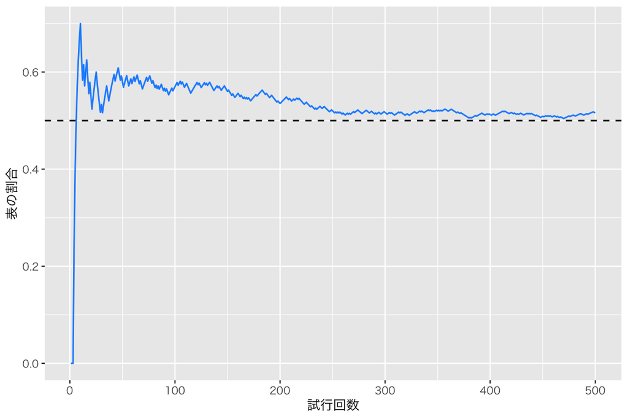

```r
df2 <- tibble(N = 1:n_flips,
              ratio_1 = ratio_1)
p1 <- ggplot(df2, aes(x = N, y = ratio_1)) +
  geom_hline(yintercept = 0.5, linetype = "dashed") +
  geom_line(color = "dodgerblue") +
  labs(x = "試行回数", y = "表の割合")
plot(p1)
```

比率が少しずつ0.5に近づいていくことがわかる。

もう1度やってみよう。

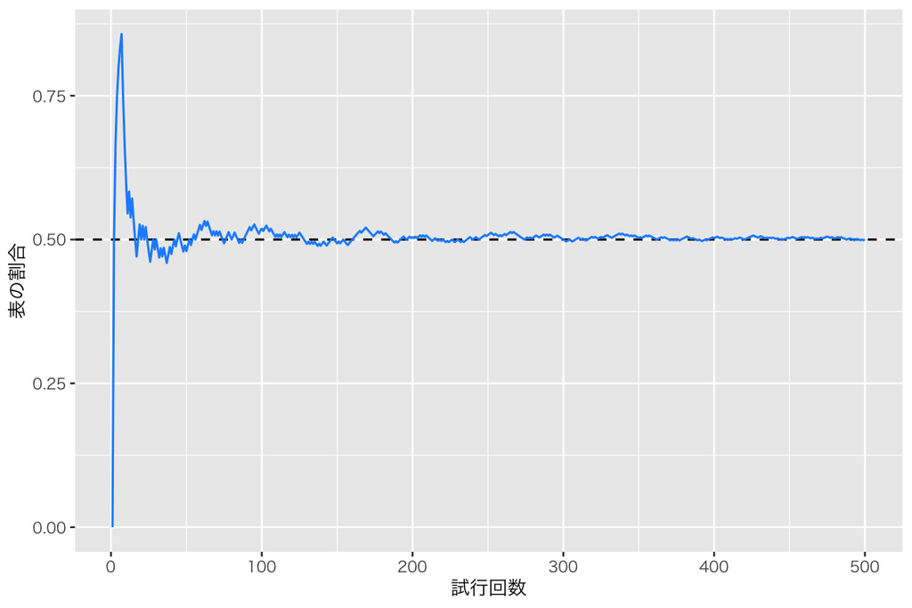

```r
ratio_2 <- rep(NA, n_flips)
coins_2 <- sample(coin, size = n_flips, replace = TRUE)
for (i in 1:n_flips) {
  n_head <- sum(coins_2[1:i] == "表") # i回目までに何回表が出たか数える
  ratio_2[i] <- n_head / i            # i回目までの表の比率を計算して記録する
}
df2$ratio_2 <- ratio_2
p2 <- ggplot(df2, aes(x = N, y = ratio_2)) +
  geom_hline(yintercept = 0.5, linetype = "dashed") +
  geom_line(color = "dodgerblue") +
  labs(x = "試行回数", y = "表の割合")
plot(p2)
```

もう1度やってみよう。

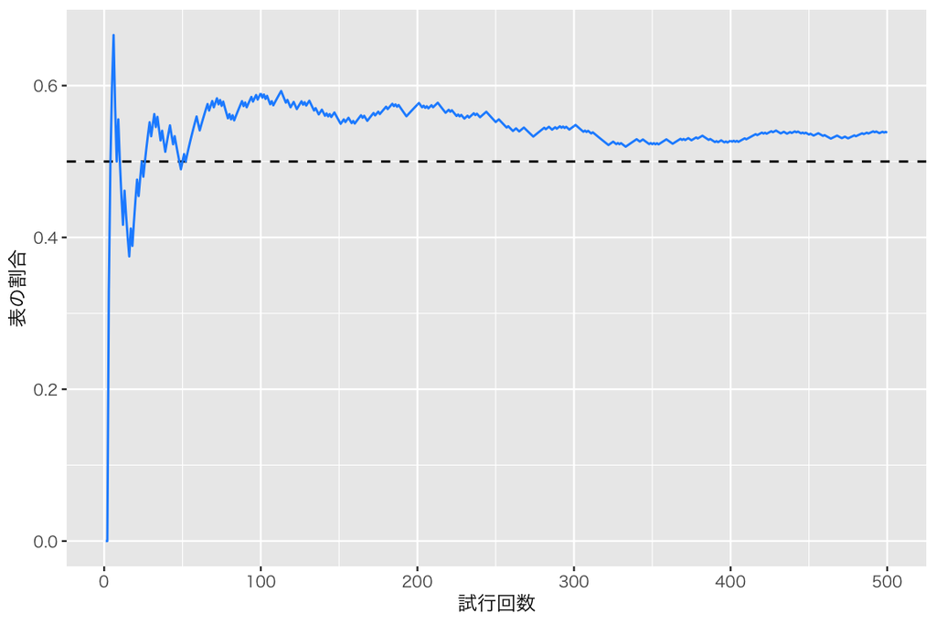

```r
ratio_3 <- rep(NA, n_flips)
coins_3 <- sample(coin, size = n_flips, replace = TRUE)
for (i in 1:n_flips) {
  n_head <- sum(coins_3[1:i] == "表") # i回目までに何回表が出たか数える
  ratio_3[i] <- n_head / i            # i回目までの表の比率を計算して記録する
}
df2$ratio_3 <- ratio_3
p3 <- ggplot(df2, aes(x = N, y = ratio_3)) +
  geom_hline(yintercept = 0.5, linetype = "dashed") +
  geom_line(color = "dodgerblue") +
  labs(x = "試行回数", y = "表の割合")
plot(p3)
```

シミュレーションを実行する度に、異なる軌跡を描きながら、比率が0.5に近づいていく様子が見てとれる。

## 実習課題

- コイン投げの回数 `n_flips` を減らしたり増やしたりして、シミュレーションを行ってみよう。
- 表が出る確率 $\theta = 0.8$, 裏が出る確率 $1-\theta = 0.2$として、同様のシミュレーションを実行してみよう。

授業の内容に戻る